# COGS2020-WEEK3-TUTORIAL

## 2. Creating basic graphs, Part 2

A). How many observations do we have for each Species of iris? Create a bar graph to visualise this information.

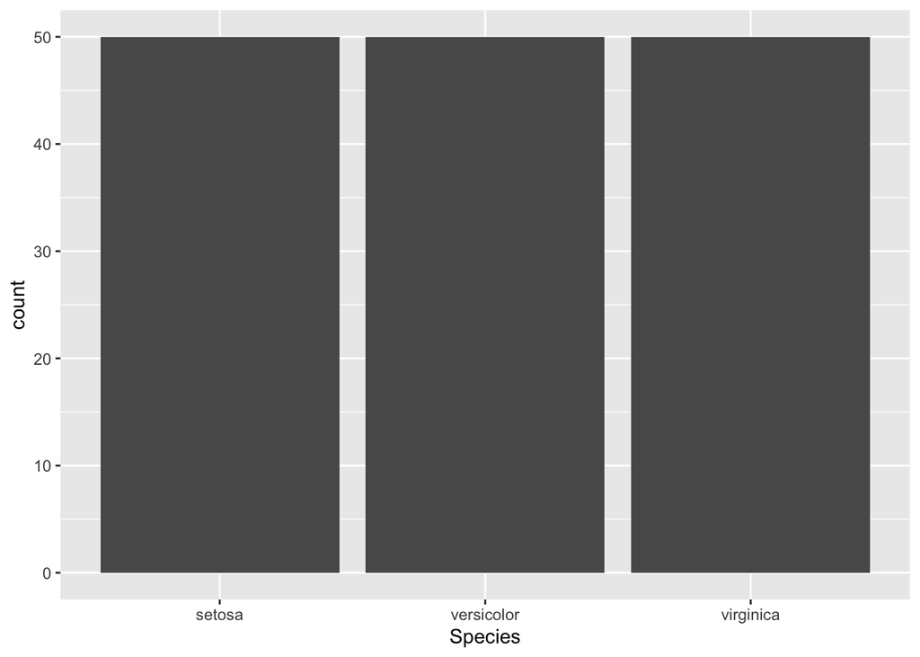

```r
ggplot(data = iris, aes(x = Species)) +
  geom_bar()
```

B). Create a boxplot graph to visualise the petal length of each Species. What do you notice?

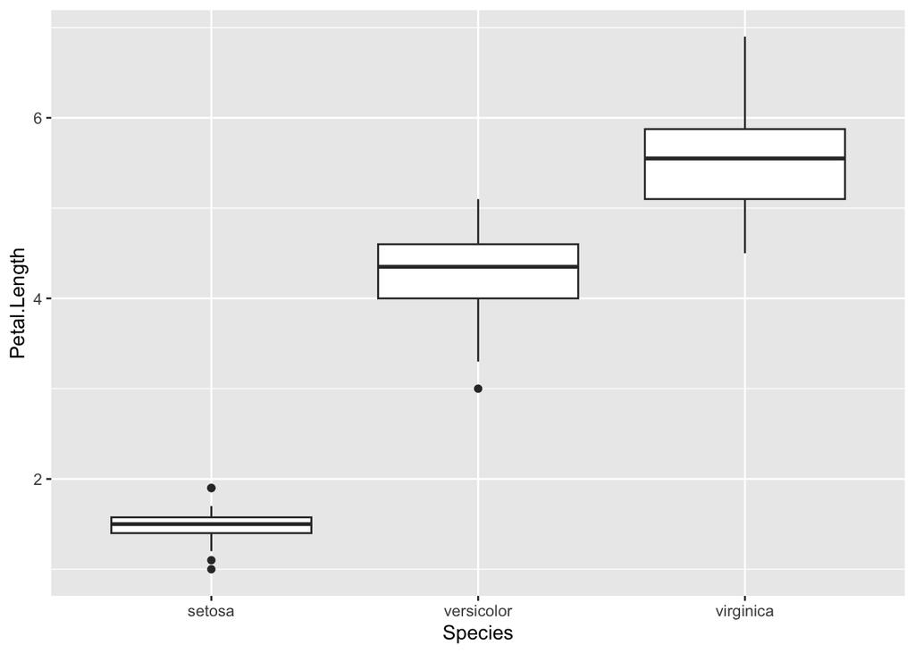

```r
ggplot(data = iris, aes(x = Species, y = Petal.Length)) +
  geom_boxplot()
```

```r
#Virginica petals are the longest, followed by Versicolor, then Setosa
#Setosa petals seem to be much shorter compared to the other 2
#But, cannot determine whether differences are significant or not without statistical testing
```

C). Create a violin graph to visualise the petal length of each Species. What else do you notice?

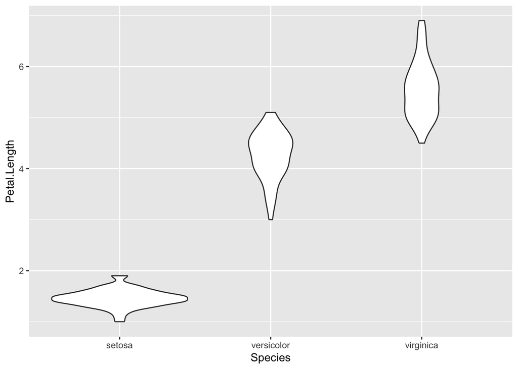

```r
ggplot(data = iris, aes(x = Species, y = Petal.Length)) +
  geom_violin()
```

```r
#Setosa petal length is more centralised compared to the others (which are more spread out)
```

## 3. Practicing aesthetics, labelling and customisation

A). Create a scatterplot where the x axis represents sepal length, the y axis represents sepal width. Give the points a colour gradient according to petal length, whereby shorter lengths are blue and longer are red. Ensure the graph is labelled appropriately (eg. title, axes labels, legend label). Finally, change the theme of the graph to classic.

[figure not shown]

```r
ggplot(data = iris, aes(x = Sepal.Length, y = Sepal.Width, colour = Petal.Length)) +
  geom_point() +
  scale_color_gradient(low = "blue", high = "red") +
  labs(title = "Sepal Dimensions Colored by Petal Length",
       x = "Sepal Width",
       y = "Sepal Length",
       colour = "Petal Length") +
  theme_classic()
```

B). Using the graph in the previous question, manually adjust the graph theme by changing the legend position to be below the graph and rotating the x axis tick marks by 45 deg.

[figure not shown]

```r
ggplot(data = iris, aes(x = Sepal.Length, y = Sepal.Width, colour = Petal.Length)) +
  geom_point() +
  scale_color_gradient(low = "blue", high = "red") +
  labs(title = "Sepal Dimensions Colored by Petal Length",
       x = "Sepal Width",
       y = "Sepal Length",
       colour = "Petal Length") +
  theme(legend.position = "bottom",
        axis.text.x = element_text(angle = 45))
```

C). First, create a histogram of sepal length. We then want to zoom in on a specific range of sepal length to focus on data points within that range. Customise the axis limits to zoom in on data that falls within c(6, 8). Adjust the binwidth accordingly. Ensure the graph is labelled appropriately (eg. title, axes labels, legend label).

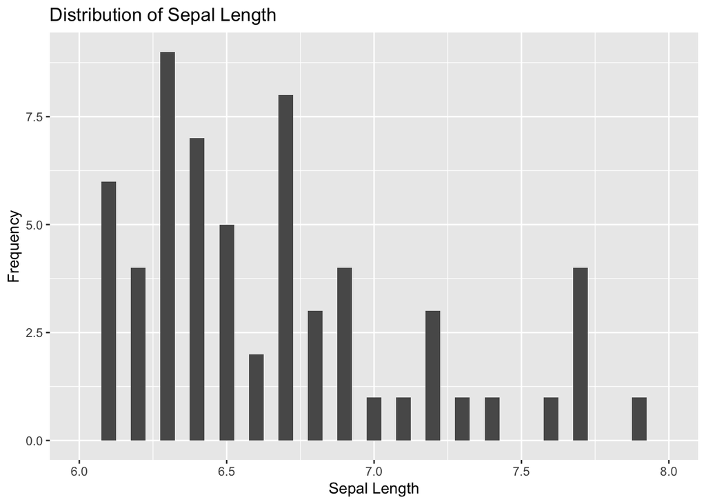

```r
ggplot(data = iris, aes(x = Sepal.Length)) +
  geom_histogram(binwidth = 0.05) +
  scale_x_continuous(limits = c(6, 8)) +
  labs(title = "Distribution of Sepal Length",
       x = "Sepal Length",
       y = "Frequency")
```

```r
# Can also use xlim(), difference is that xlim() doesn't plot data outside of the limits at all, while scale_x_continuous() still plots but rescales the axis to only show the specified range
```

## 4. Subplots and faceting

A).We want to compare the relationship between Petal Length and Petal Width across different species. Using facet_wrap() to visualise, how does the relationship between petal length and width vary depending on species?

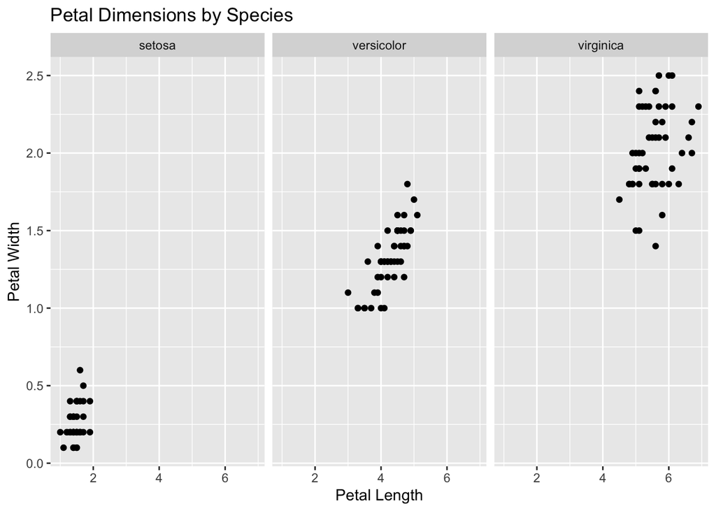

```r
ggplot(iris, aes(x = Petal.Length, y = Petal.Width)) +
  geom_point() +
  facet_wrap(~Species) +
  labs(title = "Petal Dimensions by Species",
       x = "Petal Length",
       y = "Petal Width")
```

## 5. Knit to a pdf or html

Ensure all your code will be displayed in the output (hint: check {r})

## Additional Questions - combining data.table and ggplot knowledge

A). Create a histogram on petal length only for the versicolor species. Adjust binwidth and add labels accordingly.

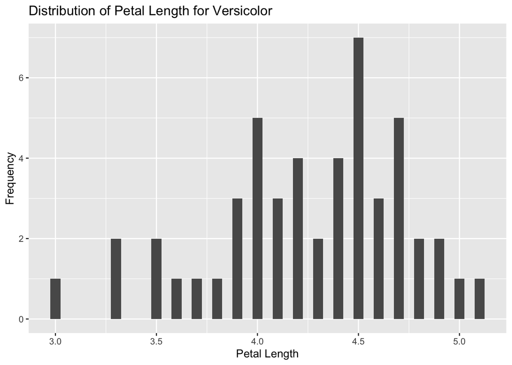

```r
ggplot(data = iris[Species == "versicolor"], aes(x = Petal.Length)) +
  geom_histogram(binwidth = 0.05) +
  labs(title = "Distribution of Petal Length for Versicolor ",
       x = "Petal Length",
       y = "Frequency")
```

B). Create a boxplot graph on sepal length only for the setosa and virginica species. Add labels accordingly.

[figure not shown]

```r
ggplot(data = iris[Species %in% c("setosa", "virginica")], aes(x = Species, y = Sepal.Length)) +
  geom_boxplot() +
  labs(title = "Distribution of Petal Length for Virginica and Setosa",
       x = "Species",
       y = "Petal Length")
```